**SYS 6018 | Fall 2020 | University of Virginia** # keyu chen # km5ar

### Problem 2.1: Bootstrapping

Bootstrap resampling can be used to quantify the uncertainty in a fitted curve.

1. Create a set of functions to generate data from the following distributions:

$$\begin{align*}
X &\sim \mathcal{U}(0, 2) \qquad \text{Uniform in $[0,2]$}\\
Y &= 1 + 2x + 5\sin(5x) + \epsilon \\
\epsilon &\sim \mathcal{N}(0,\, \sigma=2.5)
\end{align*}$$

```r
n = 100                                 # number of observations
sim_x <- function(n) runif(n,0,2)           # U[0,2]
f <- function(x) 1 + 2*x + 5*sin(5*x)   # true mean function
sd = 2.5                                  # stdev for error
x = sim_x(n)                            # get x values

sim_y <- function(x,sd){
  n = length(x)
  f(x) + rnorm(n,sd=sd)
}
```

2. Simulate $n=100$ realizations from these distributions. Produce a scatterplot and draw the true regression line $f(x) = E[Y \mid X=x]$. Use `set.seed(211)` prior to generating the data.

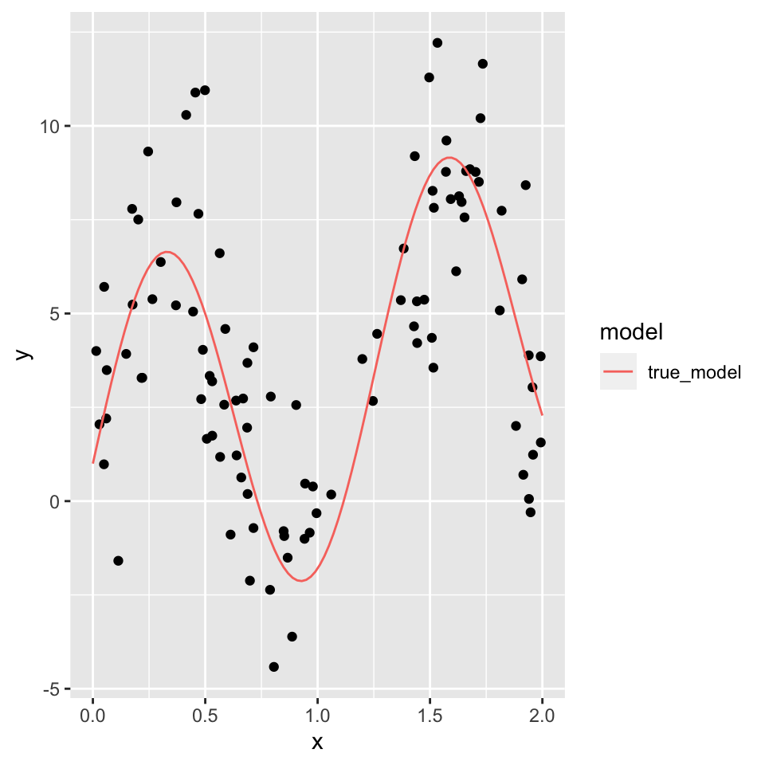

```r
# produce a scatterplot
set.seed(211)
n = 100
x = sim_x(n)
y = sim_y(x,sd=sd)
data_train = tibble(x,y)
#-- Prediction
xseq = seq(0, 2, length=100)        # sequence of 200 equally spaced values from 0 to 1
xeval = tibble(x = xseq)            # make into a tibble object
#-- Scatter plot
gg_example = ggplot(data_train, aes(x,y)) +   # a
  geom_point()
y_true <- f(xseq)
poly.data = tibble(x = xseq,true_model = y_true) %>%  # long data
  pivot_longer(-x, names_to="model", values_to="y")
gg_example +
  geom_line(data=poly.data, aes(color=model))
```

3. Now fit a 5th degree polynomial. Produce a scatterplot and draw the *estimated* regression curve.

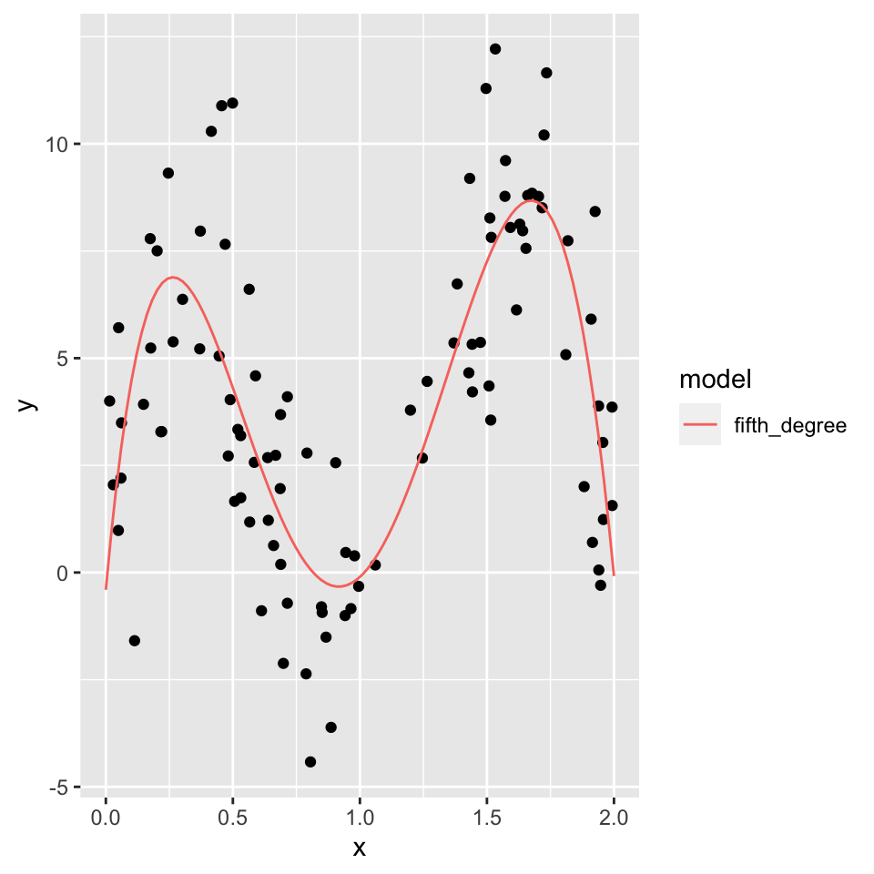

```r
# 5th degree polynomial
m2 = lm(y~poly(x, degree=5), data=data_train)
yhatc = predict(m2, newdata=xeval)
#- ggplot2 plot
poly.data = tibble(x = xseq, fifth_degree=yhatc) %>%  # long data
  pivot_longer(-x, names_to="model", values_to="y")
gg_example +
  geom_line(data=poly.data, aes(color=model))
```

4. Draw $200$ bootstrap samples, fit a 5th degree polynomial to each bootstrap sample, and make predictions at `eval.pts = seq(0, 2, length=100)`
   - Set the seed (use `set.seed(212)`) so your results are reproducible.
   - Produce a scatterplot and add the $200$ bootstrap curves

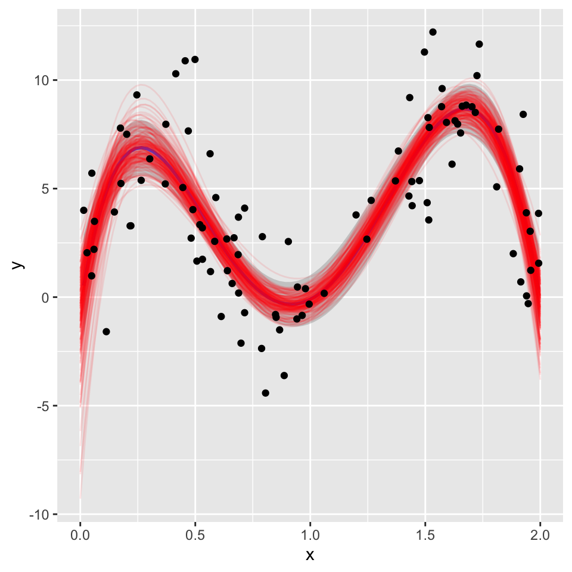

```r
#-----------------------------------------------------------------------------
#-- Bootstrap distribution
#-----------------------------------------------------------------------------
set.seed(212)                   # set random seed
M = 200                            # number of bootstrap samples
Y2 = matrix(NA,nrow(xeval), M)            # initialize vector for test statistics
for(m in 1:M){
  #- sample from empirical distribution
  ind = sample(n, replace=TRUE)    # sample indices with replacement
  data.boot = data_train[ind,]     # bootstrap sample
  #- fit regression model
  m.boot = lm(y~poly(x, degree=5), data=data.boot)
  #- save test statistics
  Y2[,m] = predict(m.boot,newdata=xeval)
}

#-- Convert to tibble and plot
data_fit = as_tibble(Y2) %>%
  bind_cols(xeval) %>%      # add the eval points
  gather(simulation, y, -x)     # convert to long format

ggplot(data_train, aes(x,y)) +
  geom_smooth(method='lm',
              formula='y~poly(x, degree=5)') +
  geom_line(data=data_fit, color="red", alpha=.10, aes(group=simulation)) +
  geom_point()
```

5. Calculate the pointwise 95% confidence intervals from the bootstrap samples. That is, for each $x \in {\rm eval.pts}$, calculate the upper and lower limits such that only 5% of the curves fall outside the interval at $x$.
   - Remake the plot from part *c*, but add the upper and lower boundaries from the 95% confidence intervals.

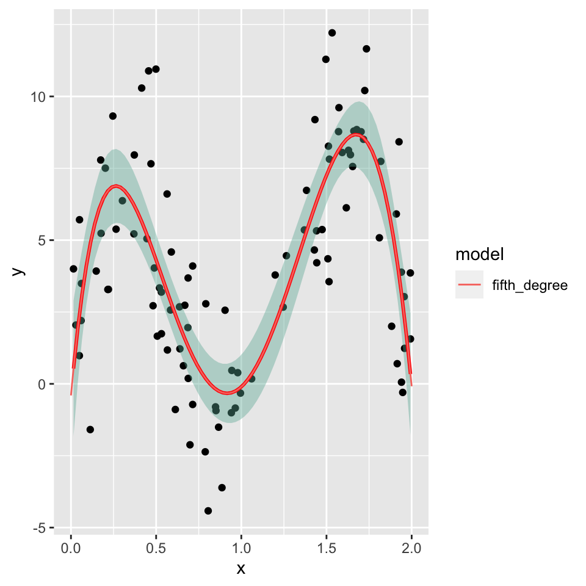

```r
# calculate the 95% pint  wise confidence interval from the bootstrap samples
confidence_intervals <-  data_train %>%
  group_by(y) %>% summarize(lower = quantile(y,0.025),upper = quantile(y,0.975))

# plug in 95% point wise confidence interval
poly.data = tibble(x = xseq, fifth_degree=yhatc) %>%  # long data
  pivot_longer(-x, names_to="model", values_to="y")
gg_example +
  geom_smooth(method='lm',
              formula='y~poly(x, degree=5)', color="red", fill="#69b3a2", se=TRUE) +
  geom_line(data=poly.data, aes(color=model))
```

### Problem 2.2: V-Fold cross-validation with $k$ nearest neighbors

Run 10-fold cross-validation on the data generated in part 1b to select the optimal $k$ in a k-nearest neighbor (kNN) model. Then evaluate how well cross-validation performed by evaluating the performance on a large test set. The steps below will guide you.

1. Use $10$-fold cross-validation to find the value of $k$ (i.e., neighborhood size) that provides the smallest cross-validated MSE using a kNN model. Search over $k=3,4,\ldots, 50$.
   - Use `set.seed(221)` prior to generating the folds to ensure the results are replicable.
   - Report the optimal $k$ (as determined by cross-validation), the corresponding estimated MSE, and produce a plot with $k$ on the x-axis and the estimated MSE on the y-axis (optional: add 1-standard error bars).

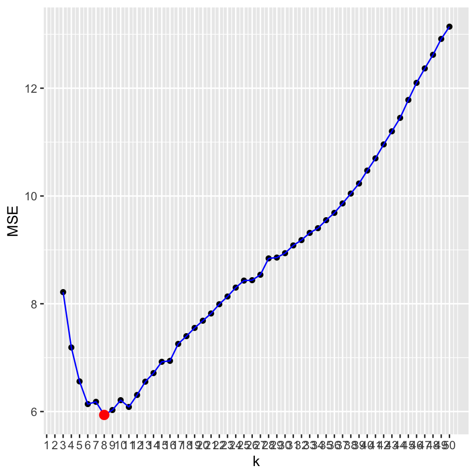

```r
set.seed(221)

knn_function <- function(data_train, data_test, k){
  knn_function_edf = numeric(length(k))
  knn_function_mse = numeric(length(k))
  for(i in 1:length(k)) {
    knn.test = knn.reg(data_train[,'x', drop=FALSE],
                       y = data_train$y,
                       test=data_test[,'x', drop=FALSE],
                       k=k[i])
    r.test = data_test$y-knn.test$pred # residuals on test data
    knn_function_edf[i] = nrow(data_train)/k[i]
    knn_function_mse[i] = mean(r.test^2)          # test MSE
  }
  tibble(k=k, mse=knn_function_mse, edf=knn_function_edf)
}

#- Get K-fold partition
n.folds = 10 # number of folds for cross-validation
fold = sample(rep(1:n.folds, length=n)) # vector of fold labels
results = tibble()
K_list = seq(3, 50, by=1)

for(j in 1:n.folds){
  #-- Set training/val data
  val = which(fold == j) # indices of validation data
  train = which(fold != j) # indices of training data
  n.val = length(val) # number of observations in validation

  results_j = knn_function(data_train[train,], data_train[val,], k=K_list)
  results = bind_rows(results,
                      results_j %>% mutate(n.val, fold=j))
}


dataframe <-  results %>%
  mutate(sse = mse*n.val) %>%
  group_by(k) %>%
  summarize(sse = sum(sse),
            mse_mu = mean(mse),
            mse_sd = sd(mse),
            se = mse_sd/sqrt(10),
            MSE=sse/nrow(data_train),
            edf=mean(edf))

# R %>% knitr::kable(digits=2)

# plot with k on the x-axis and the estimated MSE on the y-axis
dataframe %>%
  ggplot(aes(k, MSE)) + geom_point() + geom_line(color = 'blue') +
  scale_x_continuous(breaks=1:50) +
  geom_point(data=. %>% filter(MSE==min(MSE)), color="red", size=3)
```

best MSE 5.94

2. The $k$ (number of neighbors) in a kNN model determines the effective degrees of freedom *edf*. What is the optimal *edf*? Be sure to use the correct sample size when making this calculation. Produce a plot similar to that from part *a*, but use *edf* (effective degrees of freedom) on the x-axis.

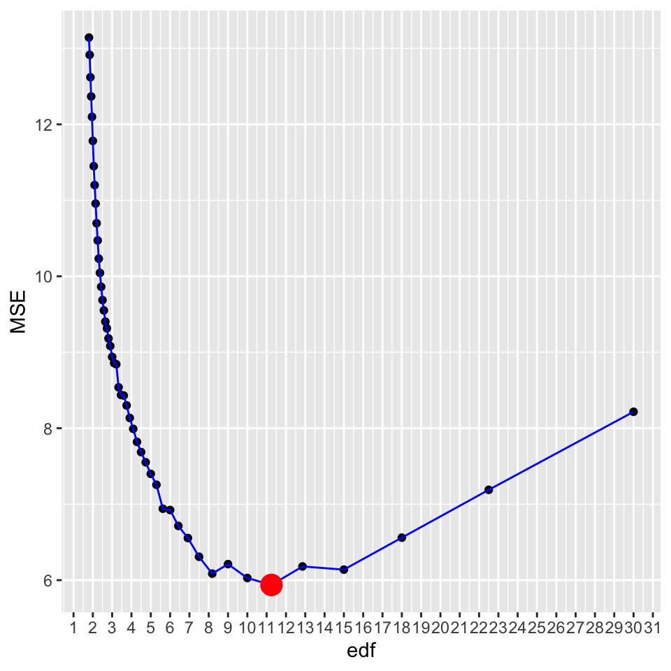

```r
# plot with edf on the x-axis and the estimated MSE on the y-axis
dataframe %>%
  ggplot(aes(edf, MSE)) +
  geom_point() +
  geom_line(color = 'blue') +
  geom_point(data=. %>% filter(MSE==min(MSE)), color="red", size=5) +
  scale_x_continuous(breaks=1:50)
```

# the optimal edf is 11.25 and the k = 8。

3. After running cross-validation, a final model fit from *all* of the training data needs to be produced to make predictions. What value of $k$ would you choose? Why?

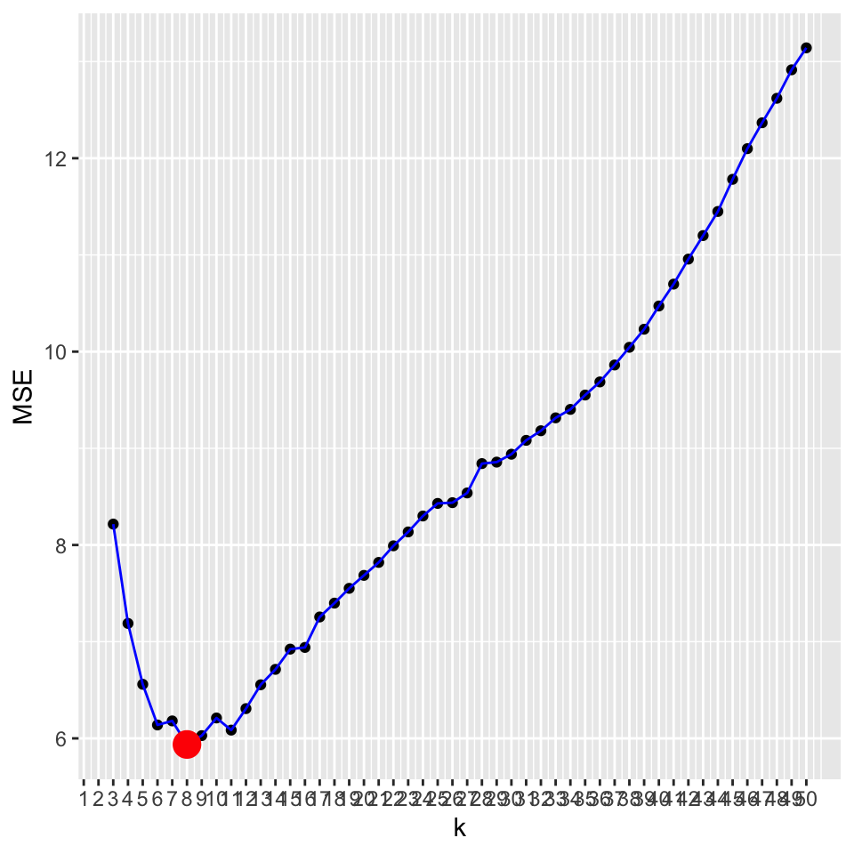

```r
# plug the data k vs mse
dataframe %>%
  ggplot(aes(k, MSE)) + geom_point() +
  geom_line(color = 'blue') +
  geom_point(data=. %>% filter(MSE==min(MSE)), color="red", size=5) +
  scale_x_continuous(breaks=1:50)
```

I would chose K = 8, because when K = 8 it has the lowest MSE. However, we also need to be aware that from k: 5-10, it all have similar MSE, which means, all of it may have a similar result.

4. Now we will see how well cross-validation performed. Simulate a test data set of $50000$ observations from the same distributions. Use `set.seed(223)` prior to generating the test data.
   - Fit a set of kNN models, using the full training data, and calculate the me2n squared error (MSE) on the test data for each model. Use the same $k$ values in *a*.
   - Report the optimal $k$, the corresponding *edf*, and MSE based on the test set.

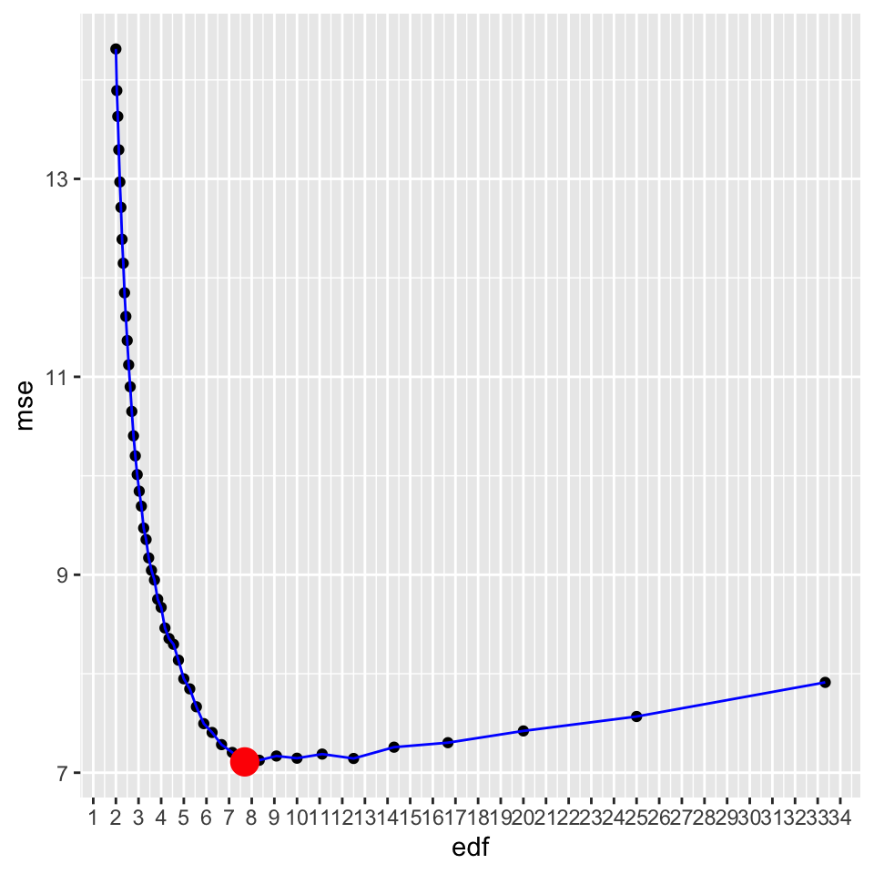

```r
# set the seed
set.seed(223)
# simulate a test set of 50000
n = 50000
x = sim_x(n)
y = f(x) + rnorm(n, sd=sd)
data_test = tibble(x,y)

Question_D <- knn_function(data_train, data_test, k=K_list)

# plug the data edf vs mse
Question_D %>%
  ggplot(aes(edf, mse)) +
  geom_point() +
  geom_line(color = 'blue') +
  geom_point(data=. %>% filter(mse==min(mse)), color="red", size=5) +
  scale_x_continuous(breaks=1:50)
```

```r
Question_D %>% filter(mse == min(mse))
```

```
#> # A tibble: 1 x 3
#>       k   mse   edf
#>   <dbl> <dbl> <dbl>
#> 1    13  7.11  7.69
```

the optimal k is 13, mse is 7.109196 and edf is 7.692308.

5. Plot both the cross-validation estimated and true test error on the same plot. See Figure 5.6 in ISL (pg 182) as a guide.
   - Produce two plots: one with $k$ on the x-axis and one with *edf* on the x-axis.

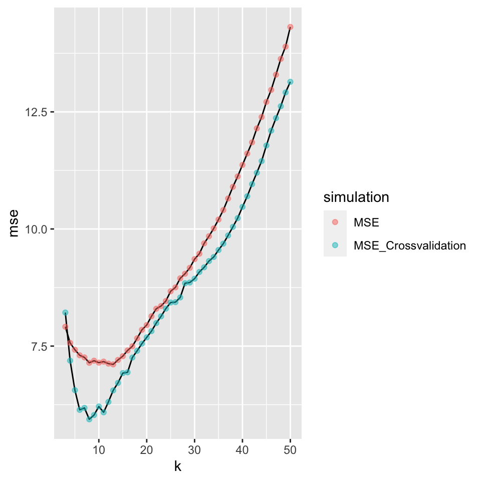

```r
Cross_validation <- dataframe[, c(1,6,7)]
df1 <- cbind(Question_D[,c(2)],Cross_validation[,c(2)])
colnames(df1) <- c('MSE','MSE_Crossvalidation')
data_k = as_tibble(df1) %>% bind_cols(Cross_validation[,1]) %>%
  gather(simulation, mse, -k)
# combine the data
df2 <- cbind(Question_D[,c(2)],Cross_validation[,c(2)])
colnames(df2) <- c('MSE','MSE_Crossvalidation')

# plug the data
ggplot(data= data_k,aes(k,mse)) +
  geom_line(aes(line=simulation,group=simulation)) +
  geom_point(alpha=0.5, aes(color=simulation,group=simulation))
```

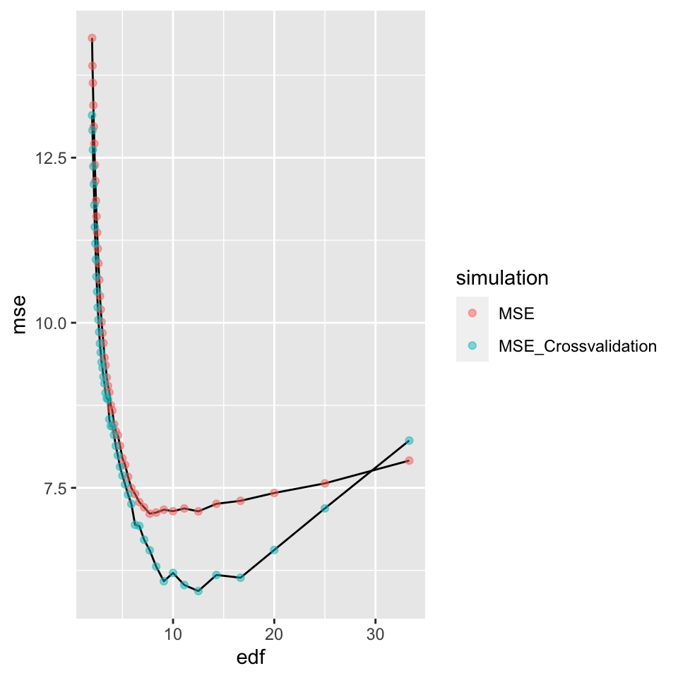

```r
# combind the data
combined_DF = as_tibble(df2) %>%
  bind_cols(Question_D[,3]) %>%
  gather(simulation, mse, -edf)

# plug the data
ggplot(data= combined_DF,aes(edf,mse)) +
  geom_line(aes(line=simulation,group=simulation)) +
  geom_point(alpha=0.5, aes(color=simulation,group=simulation))
```

6. Based on the plots from *e*, does it appear that cross-validation worked as intended? How sensitive is the choice of $k$ on the resulting test MSE?